# Bulk 1 - apical out placental organoids

Author

Giada Guntri / HRH

Published

2026-08-14

# Description

This script will generate the following plots and tables:

- Fig 2 b, d, c, j

- Supp Table 1

# 0) Preparations

## load libraries

```r
library(edgeR)
library(PCAtools)
library(sva)
library(ComplexHeatmap)
library(ggplot2)
library(ggrepel)
library(dplyr)

library(SingleCellExperiment)
library(BayesPrism)
library(forcats)
library(patchwork)
```

## new folders

```r
plot_dir <- "Paper_Figures"
if (!file.exists(plot_dir)) {
    dir.create(plot_dir, showWarnings = FALSE, recursive = FALSE)
}

table_dir <- "Paper_Tables"
if (!file.exists(table_dir)) {
    dir.create(table_dir, showWarnings = FALSE, recursive = FALSE)
}
```

## loading all the data

### original data

```r
all_counts_orig <- read.delim("3574F_raw_counts.uniqueID.20260730.tab")
rownames(all_counts_orig) <- all_counts_orig$uniqueID

# exclude day 10
all_counts_orig_selected <- all_counts_orig[,c(1:12,15:21,24:30)]
colnames(all_counts_orig_selected)
```

```
 [1] "uniqueID"   "ENSEMBLID"  "SYMBOL"     "GENENAME"   "width"
 [6] "X113_5d_MG" "X113_6d_MG" "X113_1d_SP" "X113_7d_MG" "X113_2d_SP"
[11] "X113_8d_MG" "X113_3d_SP" "Y031_5d_MG" "Y031_6d_MG" "Y031_1d_SP"
[16] "Y031_7d_MG" "Y031_2d_SP" "Y031_8d_MG" "Y031_3d_SP" "X087_5d_MG"
[21] "X087_6d_MG" "X087_1d_SP" "X087_7d_MG" "X087_2d_SP" "X087_8d_MG"
[26] "X087_3d_SP"
```

### new data

```r
all_counts_new <- read.delim("4299F_raw_counts.uniqueID.20260730.tab")
rownames(all_counts_new) <- all_counts_new$uniqueID
# exclude day 10
all_counts_new_selected <- all_counts_new[,c(1:12,15:21,24:30)]
colnames(all_counts_new_selected)
```

```
 [1] "uniqueID"   "ENSEMBLID"  "SYMBOL"     "GENENAME"   "width"
 [6] "Z143_5d_MG" "Z143_6d_MG" "Z143_1d_SP" "Z143_7d_MG" "Z143_2d_SP"
[11] "Z143_8d_MG" "Z143_3d_SP" "Z107_5d_MG" "Z107_6d_MG" "Z107_1d_SP"
[16] "Z107_7d_MG" "Z107_2d_SP" "Z107_8d_MG" "Z107_3d_SP" "Z149_5d_MG"
[21] "Z149_6d_MG" "Z149_1d_SP" "Z149_7d_MG" "Z149_2d_SP" "Z149_3d_SP"
[26] "Z149_8d_MG"
```

### combine

```r
identical(rownames(all_counts_orig_selected),rownames(all_counts_new_selected))
```

```
[1] TRUE
```

```r
all_counts_selected <- cbind(all_counts_orig_selected,all_counts_new_selected[,-c(1:5)])
colnames(all_counts_selected)
```

```
 [1] "uniqueID"   "ENSEMBLID"  "SYMBOL"     "GENENAME"   "width"
 [6] "X113_5d_MG" "X113_6d_MG" "X113_1d_SP" "X113_7d_MG" "X113_2d_SP"
[11] "X113_8d_MG" "X113_3d_SP" "Y031_5d_MG" "Y031_6d_MG" "Y031_1d_SP"
[16] "Y031_7d_MG" "Y031_2d_SP" "Y031_8d_MG" "Y031_3d_SP" "X087_5d_MG"
[21] "X087_6d_MG" "X087_1d_SP" "X087_7d_MG" "X087_2d_SP" "X087_8d_MG"
[26] "X087_3d_SP" "Z143_5d_MG" "Z143_6d_MG" "Z143_1d_SP" "Z143_7d_MG"
[31] "Z143_2d_SP" "Z143_8d_MG" "Z143_3d_SP" "Z107_5d_MG" "Z107_6d_MG"
[36] "Z107_1d_SP" "Z107_7d_MG" "Z107_2d_SP" "Z107_8d_MG" "Z107_3d_SP"
[41] "Z149_5d_MG" "Z149_6d_MG" "Z149_1d_SP" "Z149_7d_MG" "Z149_2d_SP"
[46] "Z149_3d_SP" "Z149_8d_MG"
```

```r
# fix order of day 8 in Z149
all_counts_selected <- all_counts_selected[,c(1:45,47,46)]
colnames(all_counts_selected)
```

```
 [1] "uniqueID"   "ENSEMBLID"  "SYMBOL"     "GENENAME"   "width"
 [6] "X113_5d_MG" "X113_6d_MG" "X113_1d_SP" "X113_7d_MG" "X113_2d_SP"
[11] "X113_8d_MG" "X113_3d_SP" "Y031_5d_MG" "Y031_6d_MG" "Y031_1d_SP"
[16] "Y031_7d_MG" "Y031_2d_SP" "Y031_8d_MG" "Y031_3d_SP" "X087_5d_MG"
[21] "X087_6d_MG" "X087_1d_SP" "X087_7d_MG" "X087_2d_SP" "X087_8d_MG"
[26] "X087_3d_SP" "Z143_5d_MG" "Z143_6d_MG" "Z143_1d_SP" "Z143_7d_MG"
[31] "Z143_2d_SP" "Z143_8d_MG" "Z143_3d_SP" "Z107_5d_MG" "Z107_6d_MG"
[36] "Z107_1d_SP" "Z107_7d_MG" "Z107_2d_SP" "Z107_8d_MG" "Z107_3d_SP"
[41] "Z149_5d_MG" "Z149_6d_MG" "Z149_1d_SP" "Z149_7d_MG" "Z149_2d_SP"
[46] "Z149_8d_MG" "Z149_3d_SP"
```

## set up metadata

```r
# Get only the sample columns
sample_cols <- colnames(all_counts_selected)[6:ncol(all_counts_selected)]

# Donor to sex mapping
donor_sex <- c(
  "X113" = "female",
  "Y031" = "female",
  "X087" = "male",
  "Z143" = "male",
  "Z107" = "male",
  "Z149" = "female"
)

# Create metadata
metadata <- data.frame(
  donor = sub("_.*", "", sample_cols),
  #number = seq(133, by=1, length.out = length(sample_cols)),  # adjust start number if needed
  time = as.numeric(sub(".*_(\\d+)d_.*", "\\1", sample_cols)),
  media = sub(".*_(MG|SP)$", "\\1", sample_cols),
  oxygen = "21p",
  mf = donor_sex[sub("_.*", "", sample_cols)],
  sample = paste0("X", seq(1, length(sample_cols)))
)

# Set rownames as the sample column names
rownames(metadata) <- sample_cols

# Add the time.char column as a character type
metadata <- data.frame(metadata,
                       time.char = as.character(metadata$time))
#make a factor for metadata_all$time.char
metadata$time.char <- factor(metadata$time.char, levels = c("1", "2", "3", "5","6","7","8"))

metadata <- data.frame(metadata,
                       time.med = paste(metadata$media, metadata$time))

# Make a factor for metadata$time.char with specific levels
metadata$time.med <- factor(metadata$time.med, levels = c("MG 5", "MG 6", "MG 7", "MG 8","SP 1", "SP 2", "SP 3"))

# View metadata
metadata
```

```
           donor time media oxygen     mf sample time.char time.med
X113_5d_MG  X113    5    MG    21p female     X1         5     MG 5
X113_6d_MG  X113    6    MG    21p female     X2         6     MG 6
X113_1d_SP  X113    1    SP    21p female     X3         1     SP 1
X113_7d_MG  X113    7    MG    21p female     X4         7     MG 7
X113_2d_SP  X113    2    SP    21p female     X5         2     SP 2
X113_8d_MG  X113    8    MG    21p female     X6         8     MG 8
X113_3d_SP  X113    3    SP    21p female     X7         3     SP 3
Y031_5d_MG  Y031    5    MG    21p female     X8         5     MG 5
Y031_6d_MG  Y031    6    MG    21p female     X9         6     MG 6
Y031_1d_SP  Y031    1    SP    21p female    X10         1     SP 1
Y031_7d_MG  Y031    7    MG    21p female    X11         7     MG 7
Y031_2d_SP  Y031    2    SP    21p female    X12         2     SP 2
Y031_8d_MG  Y031    8    MG    21p female    X13         8     MG 8
Y031_3d_SP  Y031    3    SP    21p female    X14         3     SP 3
X087_5d_MG  X087    5    MG    21p   male    X15         5     MG 5
X087_6d_MG  X087    6    MG    21p   male    X16         6     MG 6
X087_1d_SP  X087    1    SP    21p   male    X17         1     SP 1
X087_7d_MG  X087    7    MG    21p   male    X18         7     MG 7
X087_2d_SP  X087    2    SP    21p   male    X19         2     SP 2
X087_8d_MG  X087    8    MG    21p   male    X20         8     MG 8
X087_3d_SP  X087    3    SP    21p   male    X21         3     SP 3
Z143_5d_MG  Z143    5    MG    21p   male    X22         5     MG 5
Z143_6d_MG  Z143    6    MG    21p   male    X23         6     MG 6
Z143_1d_SP  Z143    1    SP    21p   male    X24         1     SP 1
Z143_7d_MG  Z143    7    MG    21p   male    X25         7     MG 7
Z143_2d_SP  Z143    2    SP    21p   male    X26         2     SP 2
Z143_8d_MG  Z143    8    MG    21p   male    X27         8     MG 8
Z143_3d_SP  Z143    3    SP    21p   male    X28         3     SP 3
Z107_5d_MG  Z107    5    MG    21p   male    X29         5     MG 5
Z107_6d_MG  Z107    6    MG    21p   male    X30         6     MG 6
Z107_1d_SP  Z107    1    SP    21p   male    X31         1     SP 1
Z107_7d_MG  Z107    7    MG    21p   male    X32         7     MG 7
Z107_2d_SP  Z107    2    SP    21p   male    X33         2     SP 2
Z107_8d_MG  Z107    8    MG    21p   male    X34         8     MG 8
Z107_3d_SP  Z107    3    SP    21p   male    X35         3     SP 3
Z149_5d_MG  Z149    5    MG    21p female    X36         5     MG 5
Z149_6d_MG  Z149    6    MG    21p female    X37         6     MG 6
Z149_1d_SP  Z149    1    SP    21p female    X38         1     SP 1
Z149_7d_MG  Z149    7    MG    21p female    X39         7     MG 7
Z149_2d_SP  Z149    2    SP    21p female    X40         2     SP 2
Z149_8d_MG  Z149    8    MG    21p female    X41         8     MG 8
Z149_3d_SP  Z149    3    SP    21p female    X42         3     SP 3
```

# 1) DGE: MG versus SP at individual (time) points

## prepare the metadata

```r
donor = metadata$donor
media = metadata$media
time = metadata$time
```

## generate DGEList object

We work with the raw counts

```r
all_counts_selected.asDGEList <- DGEList(counts=all_counts_selected[,-c(1:5)],genes=all_counts_selected[,c(1:5)])
```

### filter lowly expressed genes

We have 6 replicas (aka donors)

```r
mincpm <- 1
minsamples <- 6

all_counts_selected.asDGEList.cpm <- edgeR::cpm(all_counts_selected.asDGEList, log = FALSE)

all_counts_selected.asDGEList <- all_counts_selected.asDGEList[rowSums(all_counts_selected.asDGEList.cpm > mincpm) >= minsamples, , keep.lib.size=FALSE]
```

### normalization

```r
all_counts_selected.asDGEList <- calcNormFactors(all_counts_selected.asDGEList)   # same as normLibSizes(y)
```

```
calcNormFactors has been renamed to normLibSizes
```

```r
head(all_counts_selected.asDGEList$samples)
```

```
           group lib.size norm.factors
X113_5d_MG     1 30890448    1.0972380
X113_6d_MG     1 24452303    1.0611552
X113_1d_SP     1 26977690    1.0804429
X113_7d_MG     1 29657436    1.0073221
X113_2d_SP     1 30402166    0.9822224
X113_8d_MG     1 33458776    0.8996477
```

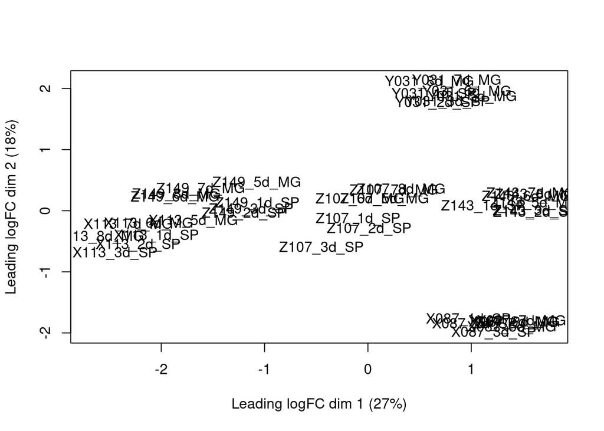

```r
plotMDS(all_counts_selected.asDGEList)
```

## setting up the design matrix

day 5

```r
MG.21p.5 <- media== "MG" & time == "5"
```

day 6

```r
MG.21p.6 <- media== "MG" & time == "6"
SP.21p.1 <- media== "SP" & time == "1"
```

day 7

```r
MG.21p.7 <- media== "MG" & time == "7"
SP.21p.2 <- media== "SP" & time == "2"
```

day 8

```r
MG.21p.8 <- media== "MG" & time == "8"
SP.21p.3 <- media== "SP" & time == "3"
```

use model.matrix (do not include MG.21p.5)

```r
design <- model.matrix(~donor+MG.21p.6+ SP.21p.1+
                              MG.21p.7+ SP.21p.2+
                              MG.21p.8+ SP.21p.3)

rownames(design) <- colnames(all_counts_selected.asDGEList)
design
```

```
           (Intercept) donorX113 donorY031 donorZ107 donorZ143 donorZ149
X113_5d_MG           1         1         0         0         0         0
X113_6d_MG           1         1         0         0         0         0
X113_1d_SP           1         1         0         0         0         0
X113_7d_MG           1         1         0         0         0         0
X113_2d_SP           1         1         0         0         0         0
X113_8d_MG           1         1         0         0         0         0
X113_3d_SP           1         1         0         0         0         0
Y031_5d_MG           1         0         1         0         0         0
Y031_6d_MG           1         0         1         0         0         0
Y031_1d_SP           1         0         1         0         0         0
Y031_7d_MG           1         0         1         0         0         0
Y031_2d_SP           1         0         1         0         0         0
Y031_8d_MG           1         0         1         0         0         0
Y031_3d_SP           1         0         1         0         0         0
X087_5d_MG           1         0         0         0         0         0
X087_6d_MG           1         0         0         0         0         0
X087_1d_SP           1         0         0         0         0         0
X087_7d_MG           1         0         0         0         0         0
X087_2d_SP           1         0         0         0         0         0
X087_8d_MG           1         0         0         0         0         0
X087_3d_SP           1         0         0         0         0         0
Z143_5d_MG           1         0         0         0         1         0
Z143_6d_MG           1         0         0         0         1         0
Z143_1d_SP           1         0         0         0         1         0
Z143_7d_MG           1         0         0         0         1         0
Z143_2d_SP           1         0         0         0         1         0
Z143_8d_MG           1         0         0         0         1         0
Z143_3d_SP           1         0         0         0         1         0
Z107_5d_MG           1         0         0         1         0         0
Z107_6d_MG           1         0         0         1         0         0
Z107_1d_SP           1         0         0         1         0         0
Z107_7d_MG           1         0         0         1         0         0
Z107_2d_SP           1         0         0         1         0         0
Z107_8d_MG           1         0         0         1         0         0
Z107_3d_SP           1         0         0         1         0         0
Z149_5d_MG           1         0         0         0         0         1
Z149_6d_MG           1         0         0         0         0         1
Z149_1d_SP           1         0         0         0         0         1
Z149_7d_MG           1         0         0         0         0         1
```

[output cut: 97 more lines]

```

attr(,"contrasts")$SP.21p.1
[1] "contr.treatment"

attr(,"contrasts")$MG.21p.7
[1] "contr.treatment"

attr(,"contrasts")$SP.21p.2
[1] "contr.treatment"

attr(,"contrasts")$MG.21p.8
[1] "contr.treatment"

attr(,"contrasts")$SP.21p.3
[1] "contr.treatment"
```

## dispersion estimation and fitting

```r
all_counts_selected.asDGEList.disp <- estimateDisp(all_counts_selected.asDGEList, design, robust = TRUE)
all_counts_selected.asDGEList.disp$common.dispersion
```

```
[1] 0.04495139
```

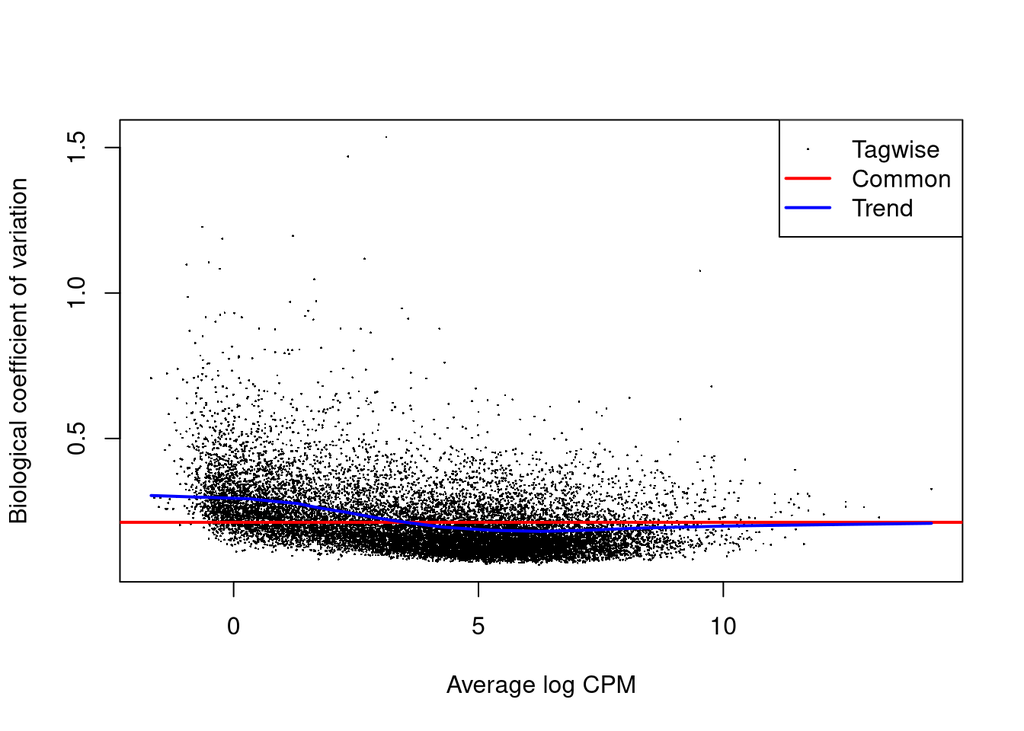

```r
plotBCV(all_counts_selected.asDGEList.disp)
```

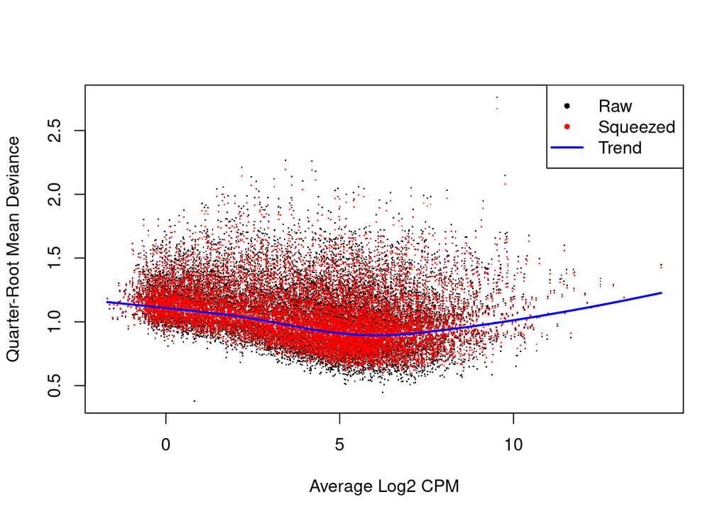

```r
fit <- glmQLFit(all_counts_selected.asDGEList.disp, design)

plotQLDisp(fit)
```

## Differential expression: Day 8 MG versus Day 8(3) SP

```r
(colnames(design) == "SP.21p.3TRUE") * 1  + (colnames(design) == "MG.21p.8TRUE") * -1
```

```
 [1]  0  0  0  0  0  0  0  0  0  0 -1  1
```

```r
qlf <- glmQLFTest(fit, contrast=as.vector((colnames(design) == "SP.21p.3TRUE") * 1  + (colnames(design) == "MG.21p.8TRUE") * -1) )

summary(decideTests(qlf))
```

```
       -1*MG.21p.8TRUE 1*SP.21p.3TRUE
Down                             1791
NotSig                          12248
Up                               1677
```

```r
summary(decideTests(qlf, p.value = 0.05, lfc = 1))
```

```
       -1*MG.21p.8TRUE 1*SP.21p.3TRUE
Down                               98
NotSig                          15279
Up                                339
```

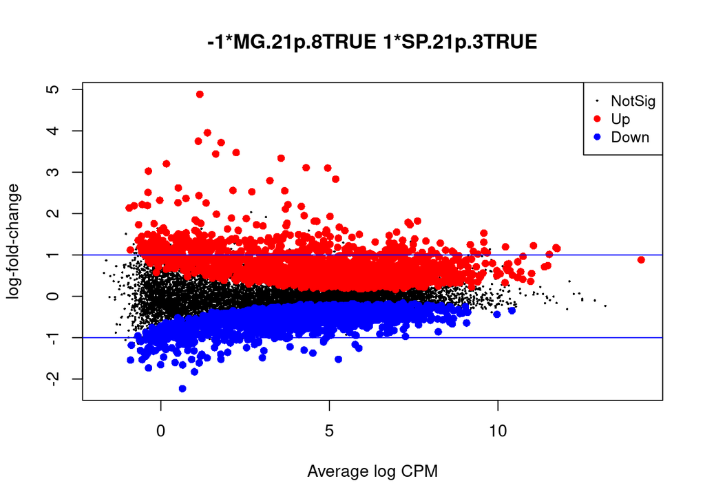

```r
plotMD(qlf)
abline(h=c(-1, 1), col="blue")
```

```r
topTags(qlf)
```

```
Coefficient:  -1*MG.21p.8TRUE 1*SP.21p.3TRUE
                             uniqueID       ENSEMBLID   SYMBOL
OGFRL1                         OGFRL1 ENSG00000119900   OGFRL1
HSPD1P10                     HSPD1P10 ENSG00000216990 HSPD1P10
DAPP1                           DAPP1 ENSG00000070190    DAPP1
RIC8A                           RIC8A ENSG00000177963    RIC8A
LAD1                             LAD1 ENSG00000159166     LAD1
NA_ENSG00000286600 NA_ENSG00000286600 ENSG00000286600     <NA>
BOK                               BOK ENSG00000176720      BOK
PPP5C                           PPP5C ENSG00000011485    PPP5C
STX4                             STX4 ENSG00000103496     STX4
HSPB1                           HSPB1 ENSG00000106211    HSPB1
                                                                     GENENAME
OGFRL1                                   opioid growth factor receptor like 1
HSPD1P10           heat shock protein family D (Hsp60) member 1 pseudogene 10
DAPP1               dual adaptor of phosphotyrosine and 3-phosphoinositides 1
RIC8A                               RIC8 guanine nucleotide exchange factor A
LAD1                                                                ladinin 1
NA_ENSG00000286600                                                       <NA>
BOK                                       BCL2 family apoptosis regulator BOK
PPP5C                                 protein phosphatase 5 catalytic subunit
STX4                                                               syntaxin 4
HSPB1                            heat shock protein family B (small) member 1
                   width      logFC   logCPM        F       PValue          FDR
OGFRL1              9176 -0.7401254 5.441953 70.26790 8.143922e-10 9.047545e-06
HSPD1P10            1676  2.4335599 1.131835 68.41065 1.151380e-09 9.047545e-06
DAPP1               4590  1.2270227 4.654409 61.59624 3.668671e-09 1.725071e-05
RIC8A               6488  0.4316871 6.764626 59.88421 5.019210e-09 1.725071e-05
LAD1                3261  1.0216900 6.106895 58.33782 6.696141e-09 1.725071e-05
NA_ENSG00000286600  1694  1.0507139 3.988868 57.69920 7.555436e-09 1.725071e-05
BOK                 2680  1.4911398 4.084315 57.61104 7.683568e-09 1.725071e-05
PPP5C               7089  0.6136215 6.634747 54.93782 1.284608e-08 2.523611e-05
STX4                4055  0.7150464 5.060255 53.04364 1.867424e-08 3.260938e-05
HSPB1               1623  1.5276035 9.580157 51.82843 2.384452e-08 3.747404e-05
```

### define up and down regulated genes

```r
tt <- as.data.frame(topTags(qlf, n = nrow(all_counts_selected.asDGEList)))

# modify the status column based on logFC and FDR
tt_modified <- tt %>%
  mutate(status = factor(case_when(
    logFC > 1 & FDR < 0.05 ~ "up",
    logFC < (-1) & FDR < 0.05 ~ "down",
    TRUE ~ "ns"
  ), levels = c("up", "ns", "down")))


write.csv(tt_modified, file = paste0(table_dir, "/Table_S1.csv"), row.names = FALSE)


# filter the data to exclude 'ns' status
tt_filtered <- tt_modified %>% filter(status != "ns")
```

### volcano plot

figure 2 d

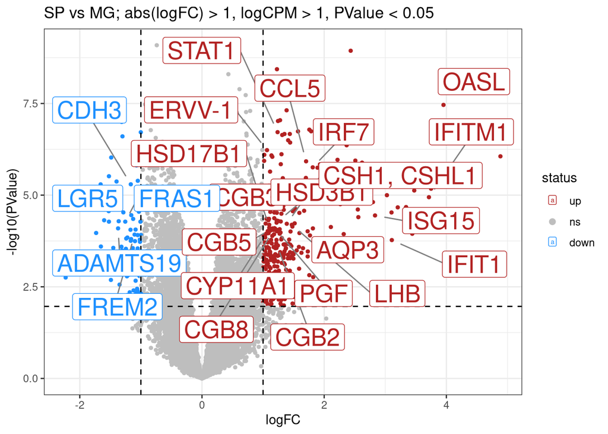

```r
# Create the volcano plot with -log10(PValue) on the y-axis
vplot <- ggplot(tt_modified, aes(x = logFC, y = -log10(PValue), color = status)) +
  geom_point(size = 1) +
  scale_color_manual(values = c("firebrick", "grey", "dodgerblue")) +
  ggtitle("SP vs MG; abs(logFC) > 1, logCPM > 1, PValue < 0.05") +
  theme(plot.title = element_text(size = 25, face = "bold.italic"),
        axis.title = element_text(size = 22, face = "bold"),
        axis.text = element_text(size = 18)) +
  guides(color = guide_legend(override.aes = list(size = 2))) +
  theme_bw() +
  geom_hline(yintercept = -log10(0.010844), linetype = "dashed", color = "black") +
  geom_vline(xintercept = 1, linetype = "dashed", color = "black") +
  geom_vline(xintercept = -1, linetype = "dashed", color = "black") +

geom_label_repel(
  data = tt_modified %>%
    filter(SYMBOL %in% c("CDH3","FRAS1", "FREM2","LGR5","ADAMTS19","IFITM1","OASL",
                         "ERVV-1","HSD3B1","CGB3", "CYP11A1","CGB5","HSD17B1", "CSH1, CSHL1","LHB","AQP3", "PGF","CGB8","CGB2",
                         "CCL5","STAT1","IRF7","ISG15","IFIT1")),
  aes(label = SYMBOL),
  size = 7,
                   box.padding = 0.5,
                   point.padding = 0.5,
                   max.overlaps = Inf,
                   segment.color = 'grey50'
  )


# display (and save) the plot
print(vplot)
```

```r
tiff(paste0(plot_dir, "/Figure_2_D.tiff"), width = 9, height = 7, units = "in", res = 300)
    print(vplot)
dev.off()
```

# 2) PCA

## Batch correction by donor using ComBat-seq

```r
all_counts_selected.CBSeq_byD <- ComBat_seq(as.matrix(all_counts_selected[,-c(1:5)]), batch=metadata$donor, group=NULL)
```

```
Found 6 batches
Using null model in ComBat-seq.
Adjusting for 0 covariate(s) or covariate level(s)
Estimating dispersions
Fitting the GLM model
Shrinkage off - using GLM estimates for parameters
Adjusting the data
```

```r
row.names(all_counts_selected.CBSeq_byD) <- row.names(all_counts_selected)
```

## PCA

PCA of batch corrected samples of a timecourse of apical-in vs apical-out analysed by bulk RNA sequencing, coloured by time and apical conformation (n=6 independent organoid lines). figure 2 b

```r
custom_colors <- c("MG 5" = '#C4DEE6',
                   "MG 6" = '#5FC5E4',
                   "MG 7" = '#1E90FF',
                   "MG 8" = '#00008F',

  "SP 1" = "#F08BC4",
  "SP 2" = "#E6007E",
  "SP 3" = "#7A004B"
)


all_counts_selected.bc.cpm.pca <- pca(edgeR::cpm(all_counts_selected.CBSeq_byD, log=TRUE),
                              metadata = metadata, removeVar = 0.1)
```

```
-- removing the lower 10% of variables based on variance
```

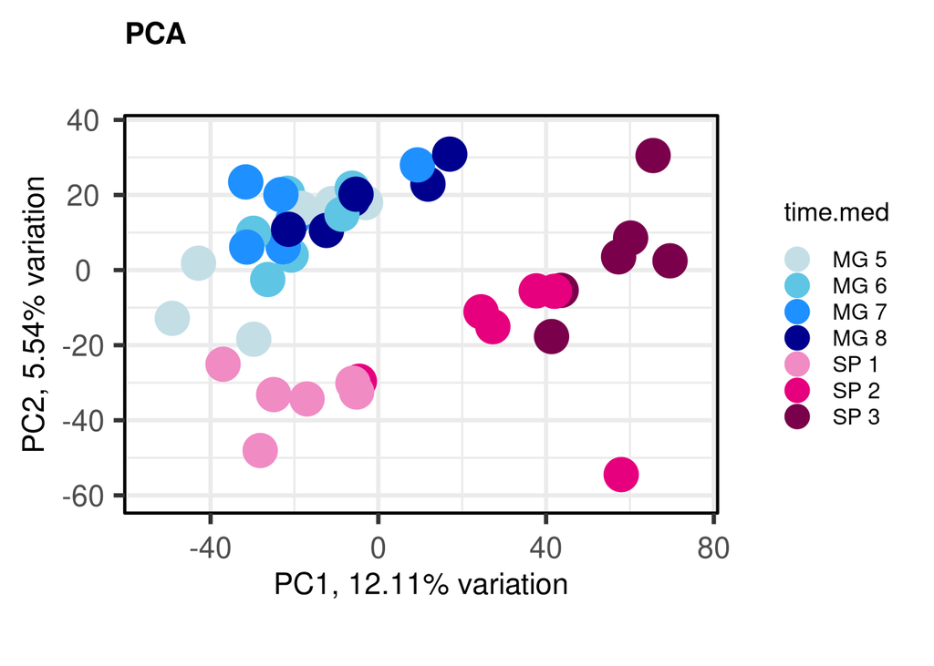

```r
# Create the biplot with custom colors
PCA <- biplot(all_counts_selected.bc.cpm.pca,
       colby = "time.med",
       legendPosition = 'right',
       title = "PCA",
       encircle = FALSE,
       lab = NULL,
       pointSize = 7.5,
       colkey = custom_colors)
#Remove the unnecessary fill label
PCA <- PCA + labs(fill = NULL)
# display (and save) the plot
PCA
```

```r
tiff(paste0(plot_dir, "/Figure_2_B.tiff"), width = 9, height = 9, units = "in", res = 300)
print(PCA)
dev.off()
```

# 3) Heatmap

Heatmap depicting batch corrected centered and scaled counts per million (cpm) of selected genes across the apical-in and apical-out time course. Figure 2 c

## defining genes

```r
VCT <- c(
  "EPCAM",
  "CDH1",
  "ITGA6",
  "TP63",
  "PCNA",
  "MKI67",
  "CCNA2",
  "FRAS1",
  "ADAMTS19",
  "TNIK",
  "WLS",
  "BMP7",
  "LGR5",
  "CDH3"
)

VCT_fusing <- c(
  "SLC1A5",
  "OVOL1",
  "GCM1",
  "MFSD2A",
  "ENDOU"
)

SYN <- c(
  "IGF2BP2",
  "RELL2",
  "TCL1B",
  "ERVW-1",
  "ERVFRD-1",
  "ERVV-1",
  "ERVV-2",
  "ERV3-1",
  "SDC1",
  "EPS8L1",
  "CYP19A1"
)

SYN_hormones <- c(
  "GDF15",
  "PAPPA2",
  "KISS1",
  "CGA",
  "CGB3",
  "CSH1, CSHL1",
  "PSG2",
  "PSG3",
  "PSG6"
)

genes1.1 <- c(VCT, VCT_fusing, SYN, SYN_hormones)

genes1.1 <- c(VCT,VCT_fusing, SYN, SYN_hormones)
genes1.1
```

```
 [1] "EPCAM"       "CDH1"        "ITGA6"       "TP63"        "PCNA"
 [6] "MKI67"       "CCNA2"       "FRAS1"       "ADAMTS19"    "TNIK"
[11] "WLS"         "BMP7"        "LGR5"        "CDH3"        "SLC1A5"
[16] "OVOL1"       "GCM1"        "MFSD2A"      "ENDOU"       "IGF2BP2"
[21] "RELL2"       "TCL1B"       "ERVW-1"      "ERVFRD-1"    "ERVV-1"
[26] "ERVV-2"      "ERV3-1"      "SDC1"        "EPS8L1"      "CYP19A1"
[31] "GDF15"       "PAPPA2"      "KISS1"       "CGA"         "CGB3"
[36] "CSH1, CSHL1" "PSG2"        "PSG3"        "PSG6"
```

## data to plot

### calculate cpm values

```r
all_counts_selected.bc.cpm <-edgeR::cpm(all_counts_selected.CBSeq_byD, log=FALSE)
```

## assemble data in custom order

```r
data2plot1bc <- data.frame()

for (gene in genes1.1) {
    data2plot1bc <- rbind(data2plot1bc, all_counts_selected.bc.cpm[rownames(all_counts_selected.bc.cpm) == gene,])
}


rownames(data2plot1bc) <- genes1.1

colnames(data2plot1bc) <- colnames(all_counts_selected.bc.cpm)

data2plot1bc.sc <- t(scale(t(data2plot1bc)))

custom_order <- c(
  grep("X113_5d_MG", colnames(data2plot1bc.sc), value = TRUE),
  grep("Y031_5d_MG", colnames(data2plot1bc.sc), value = TRUE),
  grep("X087_5d_MG", colnames(data2plot1bc.sc), value = TRUE),
  grep("Z143_5d_MG", colnames(data2plot1bc.sc), value = TRUE),
  grep("Z107_5d_MG", colnames(data2plot1bc.sc), value = TRUE),
  grep("Z149_5d_MG", colnames(data2plot1bc.sc), value = TRUE),
  grep("X113_6d_MG", colnames(data2plot1bc.sc), value = TRUE),
  grep("Y031_6d_MG", colnames(data2plot1bc.sc), value = TRUE),
  grep("X087_6d_MG", colnames(data2plot1bc.sc), value = TRUE),
  grep("Z143_6d_MG", colnames(data2plot1bc.sc), value = TRUE),
  grep("Z107_6d_MG", colnames(data2plot1bc.sc), value = TRUE),
  grep("Z149_6d_MG", colnames(data2plot1bc.sc), value = TRUE),
  grep("X113_7d_MG", colnames(data2plot1bc.sc), value = TRUE),
  grep("Y031_7d_MG", colnames(data2plot1bc.sc), value = TRUE),
  grep("X087_7d_MG", colnames(data2plot1bc.sc), value = TRUE),
  grep("Z143_7d_MG", colnames(data2plot1bc.sc), value = TRUE),
  grep("Z107_7d_MG", colnames(data2plot1bc.sc), value = TRUE),
  grep("Z149_7d_MG", colnames(data2plot1bc.sc), value = TRUE),
  grep("X113_8d_MG", colnames(data2plot1bc.sc), value = TRUE),
  grep("Y031_8d_MG", colnames(data2plot1bc.sc), value = TRUE),
  grep("X087_8d_MG", colnames(data2plot1bc.sc), value = TRUE),
  grep("Z143_8d_MG", colnames(data2plot1bc.sc), value = TRUE),
  grep("Z107_8d_MG", colnames(data2plot1bc.sc), value = TRUE),
  grep("Z149_8d_MG", colnames(data2plot1bc.sc), value = TRUE),
  grep("X113_1d_SP", colnames(data2plot1bc.sc), value = TRUE),
  grep("Y031_1d_SP", colnames(data2plot1bc.sc), value = TRUE),
  grep("X087_1d_SP", colnames(data2plot1bc.sc), value = TRUE),
  grep("Z143_1d_SP", colnames(data2plot1bc.sc), value = TRUE),
  grep("Z107_1d_SP", colnames(data2plot1bc.sc), value = TRUE),
  grep("Z149_1d_SP", colnames(data2plot1bc.sc), value = TRUE),
  grep("X113_2d_SP", colnames(data2plot1bc.sc), value = TRUE),
  grep("Y031_2d_SP", colnames(data2plot1bc.sc), value = TRUE),
  grep("X087_2d_SP", colnames(data2plot1bc.sc), value = TRUE),
  grep("Z143_2d_SP", colnames(data2plot1bc.sc), value = TRUE),
  grep("Z107_2d_SP", colnames(data2plot1bc.sc), value = TRUE),
  grep("Z149_2d_SP", colnames(data2plot1bc.sc), value = TRUE),
  grep("X113_3d_SP", colnames(data2plot1bc.sc), value = TRUE),
  grep("Y031_3d_SP", colnames(data2plot1bc.sc), value = TRUE),
  grep("X087_3d_SP", colnames(data2plot1bc.sc), value = TRUE),
  grep("Z143_3d_SP", colnames(data2plot1bc.sc), value = TRUE),
  grep("Z107_3d_SP", colnames(data2plot1bc.sc), value = TRUE),
  grep("Z149_3d_SP", colnames(data2plot1bc.sc), value = TRUE)
)

data2plot1bc.sc <- data2plot1bc.sc[, custom_order]
```

## and plot

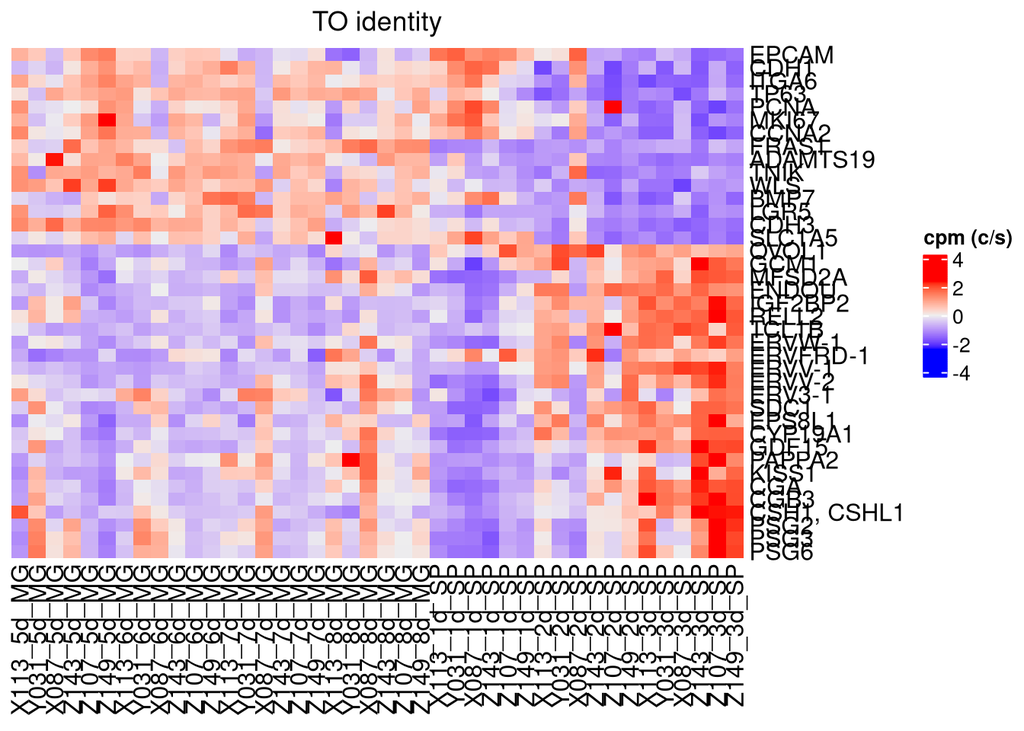

```r
plot <- Heatmap(data2plot1bc.sc, cluster_columns=FALSE, cluster_rows=FALSE,
                   heatmap_legend_param = list(title = "cpm (c/s)", color_bar = "continuous"),
                   column_title = "TO identity",
                   bottom_annotation = NULL)

# display (and save) the plot
plot
```

```r
tiff(paste0(plot_dir, "/Figure_2_C.tiff"), width = 9, height = 7, units = "in", res = 300)
    print(plot)
dev.off()
```

## 4) Deconvolution

Deconvolution of the bulk RNA sequencing using:

- single cell data: “Wang 2024 data” (“early” data set, only eCTB, eCTB_fusion and eSTB

```r
sc_data_file <- "sc_data/placenta.rna.8w_rna.20260730.as_sce.with_add_paper_clusters.20260730.eCTB_eSTB_only.rds"
#The dataset can be regenerated using:
# preparing_Wang2024_data.qmd
```

```r
date()
```

```
[1] "Wed Oct 14 18:08:50 2026"
```

```r
today<- format(Sys.Date(), format="%Y%m%d")

directory <- paste("deconvolution.BayesPrism.Wang2024",today, sep = "")
if (!file.exists(directory)) {
  dir.create(file.path(getwd(), directory))
}
```

## getting the data

### select apical-in (day 8 matrigel) and apical-out (day 3 supsension) end points

```r
selected_counts <- all_counts_selected[,c(grep("8d_MG",colnames(all_counts_selected)),grep("3d_SP",colnames(all_counts_selected)))]
colnames(selected_counts)
```

```
 [1] "X113_8d_MG" "Y031_8d_MG" "X087_8d_MG" "Z143_8d_MG" "Z107_8d_MG"
 [6] "Z149_8d_MG" "X113_3d_SP" "Y031_3d_SP" "X087_3d_SP" "Z143_3d_SP"
[11] "Z107_3d_SP" "Z149_3d_SP"
```

### transpose bulk data

from the vignete: bk.dat : The sample-by-gene raw count matrix of bulk RNA-seq expression. rownames are bulk sample IDs, while colnames are gene names/IDs.

```r
bk.dat <- t(selected_counts)
bk.dat[,1:5]
```

```
           TSPAN6 TNMD DPM1 SCYL3 FIRRM
X113_8d_MG    533    0 1770   579   571
Y031_8d_MG    472    0 1513   667   528
X087_8d_MG    304    0  923   422   222
Z143_8d_MG    302    0 1761   438   360
Z107_8d_MG    418    0 1546   584   478
Z149_8d_MG    508    0  886   391   485
X113_3d_SP    566    0 1649   456   437
Y031_3d_SP    377    0 1311   484   406
X087_3d_SP    449    0 1586   483   367
Z143_3d_SP    242    0 1575   419   196
Z107_3d_SP    348    0 1081   405   277
Z149_3d_SP    379    0  851   399   302
```

[figure not shown]

## get sc/snRNA-seq data

```r
sce <- readRDS(sc_data_file)
sce
```

```
class: SingleCellExperiment
dim: 29132 24189
metadata(0):
assays(3): counts data scale.data
rownames(29132): AL627309.1 AL627309.2 ... BX546450.2 PNMA3
rowData names(5): vst.mean vst.variance vst.variance.expected
  vst.variance.standardized vst.variable
colnames(24189): PLA-rna-early1_AAACCCAAGCAATAAC-1
  PLA-rna-early1_AAACCCACACCCAATA-1 ...
  PLA-rna-early6_TTTGTTGTCGGCTTCT-1 PLA-rna-early6_TTTGTTGTCGTCTAAG-1
colData names(58): orig.ident nCount_RNA ... paper_clusters
  paper_clusters_name
reducedDimNames(4): pca UMAP tsne umap_rotate
mainExpName: NULL
altExpNames(0):
```

```r
table(sce$paper_clusters)
```

```
   1   10   11    2    3    4    5    6    7    8    9
2556 2896  536 2284 2275 5445 1895 1776 1693 1532 1301
```

```r
table(sce$paper_clusters_name)
```

```
            eCTB 1             eCTB 2        eCTB fusion eCTB proliferation
              1301               1776                536               1693
     eSTB mature 1      eSTB mature 2         eSTB mixed       eSTB nascent
              2896               2275               7340               1532
  eSTB premature 1   eSTB premature 2
              2284               2556
```

### convert to (dense) matrix (and transpose)

```r
sc.dat <- t(as.matrix(assay(sce)))
dim(sc.dat)
```

```
[1] 24189 29132
```

```r
head(rownames(sc.dat))
```

```
[1] "PLA-rna-early1_AAACCCAAGCAATAAC-1" "PLA-rna-early1_AAACCCACACCCAATA-1"
[3] "PLA-rna-early1_AAACCCACAGAACGCA-1" "PLA-rna-early1_AAACCCACATGGCCCA-1"
[5] "PLA-rna-early1_AAACCCAGTCAAGCCC-1" "PLA-rna-early1_AAACCCATCATGCCCT-1"
```

```r
head(colnames(sc.dat))
```

```
[1] "AL627309.1" "AL627309.2" "AL732372.1" "AC114498.1" "AL669831.2"
[6] "AL669831.5"
```

## compare gene identifiers

```r
length(colnames(sc.dat))
```

```
[1] 29132
```

```r
length(colnames(bk.dat))
```

```
[1] 60605
```

```r
sum(colnames(sc.dat) %in% colnames(bk.dat))
```

```
[1] 18451
```

```r
sum(colnames(bk.dat) %in% colnames(sc.dat))
```

```
[1] 18451
```

```r
colnames(colData(sce))
```

```
 [1] "orig.ident"                       "nCount_RNA"
 [3] "nFeature_RNA"                     "percent.mt"
 [5] "percent.ribo"                     "percent.hb"
 [7] "percent.xist"                     "percent.chrY"
 [9] "S.Score"                          "G2M.Score"
[11] "Phase"                            "RNA_snn_res.0.9"
[13] "pANN_0.25_0.09_950"               "DF.classifications_0.25_0.09_950"
[15] "sex"                              "sample"
[17] "pANN_0.25_0.09_591"               "DF.classifications_0.25_0.09_591"
[19] "RNA_snn_res.1"                    "pANN_0.25_0.09_761"
[21] "DF.classifications_0.25_0.09_761" "pANN_0.25_0.09_810"
[23] "DF.classifications_0.25_0.09_810" "pANN_0.25_0.09_686"
[25] "DF.classifications_0.25_0.09_686" "pANN_0.25_0.09_928"
[27] "DF.classifications_0.25_0.09_928" "RNA_snn_res.1.2"
[29] "pANN"                             "DF.classifications"
[31] "RNA_snn_res.0.1"                  "RNA_snn_res.0.2"
[33] "RNA_snn_res.0.3"                  "RNA_snn_res.0.4"
[35] "RNA_snn_res.0.5"                  "RNA_snn_res.0.6"
[37] "RNA_snn_res.0.7"                  "RNA_snn_res.0.8"
[39] "RNA_snn_res.1.1"                  "RNA_snn_res.1.3"
[41] "RNA_snn_res.1.4"                  "RNA_snn_res.1.5"
[43] "RNA_snn_res.1.6"                  "RNA_snn_res.1.7"
[45] "RNA_snn_res.1.8"                  "RNA_snn_res.1.9"
[47] "RNA_snn_res.2"                    "RNA_snn_res.0.65"
[49] "cluster"                          "seurat_clusters"
[51] "RNA_snn_res.2.1"                  "RNA_snn_res.2.2"
[53] "RNA_snn_res.2.3"                  "RNA_snn_res.2.4"
[55] "RNA_snn_res.2.5"                  "RNA_snn_res.1.35"
[57] "paper_clusters"                   "paper_clusters_name"
```

### generate BP cell.type.labels

```r
cell.type.labels <- as.character(colData(sce)[,"paper_clusters_name"])
table(cell.type.labels)
```

```
cell.type.labels
            eCTB 1             eCTB 2        eCTB fusion eCTB proliferation
              1301               1776                536               1693
     eSTB mature 1      eSTB mature 2         eSTB mixed       eSTB nascent
              2896               2275               7340               1532
  eSTB premature 1   eSTB premature 2
              2284               2556
```

### generate cell.state.labels

from the vignette: Define multiple cell states for cell types of significant heterogeneity, such as malignant cells, and of interest to deconvolve their transcription. this is currently not the case fo now use: cell.state.labels <- cell.type.labels see: https://github.com/Danko-Lab/BayesPrism/issues/66

```r
cell.state.labels <- as.character(colData(sce)[,"paper_clusters_name"])

table(cbind.data.frame(cell.state.labels, cell.type.labels))
```

```
                    cell.type.labels
cell.state.labels    eCTB 1 eCTB 2 eCTB fusion eCTB proliferation eSTB mature 1
  eCTB 1               1301      0           0                  0             0
  eCTB 2                  0   1776           0                  0             0
  eCTB fusion             0      0         536                  0             0
  eCTB proliferation      0      0           0               1693             0
  eSTB mature 1           0      0           0                  0          2896
  eSTB mature 2           0      0           0                  0             0
  eSTB mixed              0      0           0                  0             0
  eSTB nascent            0      0           0                  0             0
  eSTB premature 1        0      0           0                  0             0
  eSTB premature 2        0      0           0                  0             0
                    cell.type.labels
cell.state.labels    eSTB mature 2 eSTB mixed eSTB nascent eSTB premature 1
  eCTB 1                         0          0            0                0
  eCTB 2                         0          0            0                0
  eCTB fusion                    0          0            0                0
  eCTB proliferation             0          0            0                0
  eSTB mature 1                  0          0            0                0
  eSTB mature 2               2275          0            0                0
  eSTB mixed                     0       7340            0                0
  eSTB nascent                   0          0         1532                0
  eSTB premature 1               0          0            0             2284
  eSTB premature 2               0          0            0                0
                    cell.type.labels
cell.state.labels    eSTB premature 2
  eCTB 1                            0
  eCTB 2                            0
  eCTB fusion                       0
  eCTB proliferation                0
  eSTB mature 1                     0
  eSTB mature 2                     0
  eSTB mixed                        0
  eSTB nascent                      0
  eSTB premature 1                  0
  eSTB premature 2               2556
```

## QC of cell type and state labels

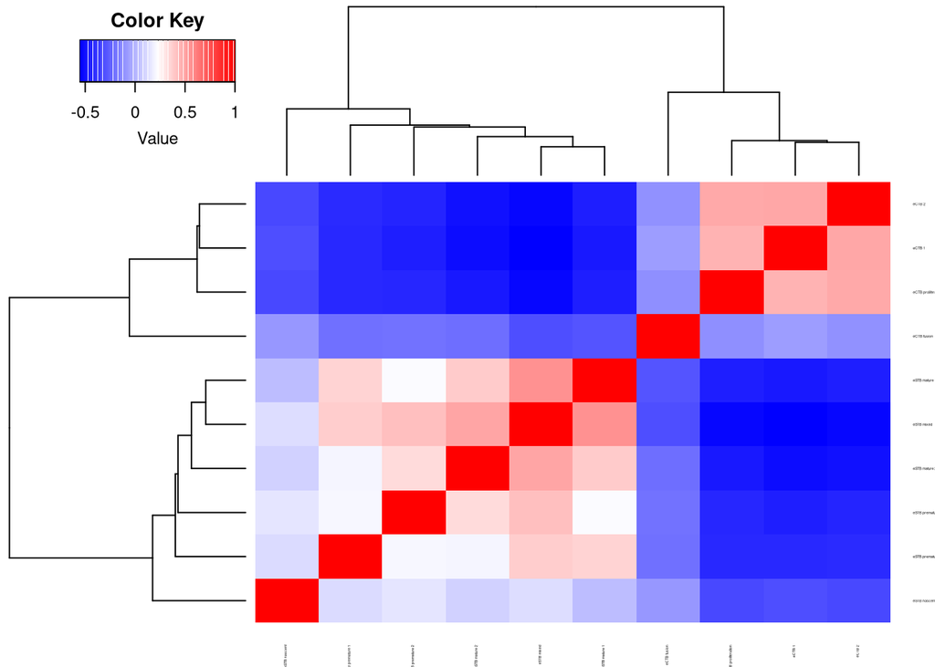

```r
plot.cor.phi (input=sc.dat,
              input.labels=cell.state.labels,
              title="cell state (aka 'cell_type') correlation",
              cexRow=0.2, cexCol=0.2,
              margins=c(2,2)
)
```

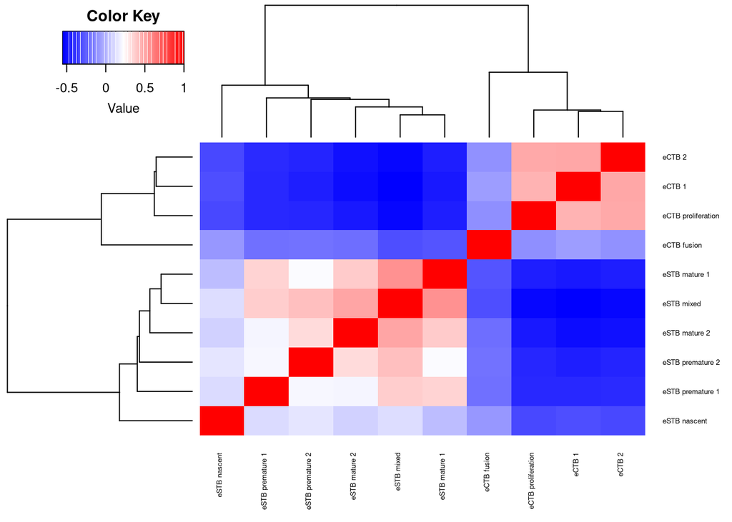

```r
# this is the same in our case
plot.cor.phi (input=sc.dat,
              input.labels=cell.type.labels,
              title="cell type (aka 'cell_type') correlation",
              cexRow=0.5, cexCol=0.5,
)
```

## Filter outlier genes and select marker genes

### filtering

```
Gene symbols detected. Recommend to use EMSEMBLE IDs for more unique mapping.
```

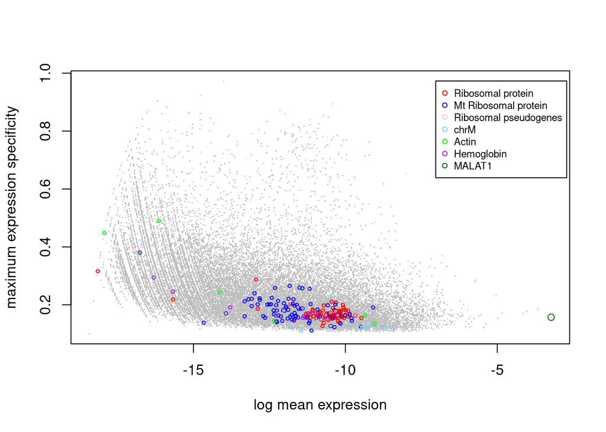

```r
#| label: outliers I
sc.stat <- plot.scRNA.outlier(input=sc.dat,
                              cell.type.labels=cell.type.labels,
                              species="hs",
                              return.raw=TRUE
)
```

```r
head(sc.stat)
```

```
           exp.mean.log  max.spec other_Rb  chrM  chrX  chrY    Rb   Mrp   act
AL627309.1    -12.94784 0.1717132    FALSE FALSE FALSE FALSE FALSE FALSE FALSE
AL627309.2    -16.94389 0.4540420    FALSE FALSE FALSE FALSE FALSE FALSE FALSE
AL732372.1    -14.72382 0.3078773    FALSE FALSE FALSE FALSE FALSE FALSE FALSE
AC114498.1    -11.82899 0.2532788    FALSE FALSE FALSE FALSE FALSE FALSE FALSE
AL669831.2    -16.07531 0.2540195    FALSE FALSE FALSE FALSE FALSE FALSE FALSE
AL669831.5    -10.80391 0.2486200    FALSE FALSE FALSE FALSE FALSE FALSE FALSE
              hb MALAT1
AL627309.1 FALSE  FALSE
AL627309.2 FALSE  FALSE
AL732372.1 FALSE  FALSE
AC114498.1 FALSE  FALSE
AL669831.2 FALSE  FALSE
AL669831.5 FALSE  FALSE
```

```
Gene symbols detected. Recommend to use EMSEMBLE IDs for more unique mapping.
```

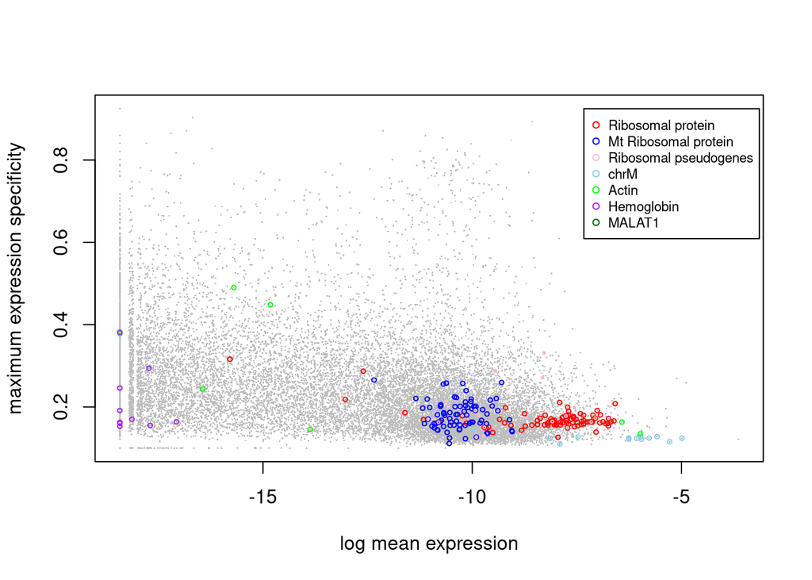

```r
#| label: outliers II
bk.stat <- plot.bulk.outlier(bulk.input=bk.dat,
                             sc.input=sc.dat,
                             cell.type.labels=cell.type.labels,
                             species="hs",
                             return.raw=TRUE
)
```

```r
head(bk.stat)
```

```
       exp.mean.log  max.spec other_Rb  chrM  chrX  chrY    Rb   Mrp   act
TSPAN6   -11.101979 0.2364797    FALSE FALSE  TRUE FALSE FALSE FALSE FALSE
TNMD     -18.420681        NA    FALSE FALSE  TRUE FALSE FALSE FALSE FALSE
DPM1      -9.909311 0.1276130    FALSE FALSE FALSE FALSE FALSE FALSE FALSE
SCYL3    -10.947333 0.1666420    FALSE FALSE FALSE FALSE FALSE FALSE FALSE
FIRRM    -11.163764        NA    FALSE FALSE FALSE FALSE FALSE FALSE FALSE
FGR      -17.929389 0.3692491    FALSE FALSE FALSE FALSE FALSE FALSE FALSE
          hb MALAT1
TSPAN6 FALSE  FALSE
TNMD   FALSE  FALSE
DPM1   FALSE  FALSE
SCYL3  FALSE  FALSE
FIRRM  FALSE  FALSE
FGR    FALSE  FALSE
```

```r
#| label: filter
sc.dat.filtered <- cleanup.genes (input=sc.dat,
                                  input.type="count.matrix",
                                  species="hs",
                                  gene.group=c("Rb","Mrp","other_Rb","chrM","MALAT1","chrX","chrY"),
                                  exp.cells=5)
```

```
Gene symbols detected. Recommend to use EMSEMBLE IDs for more unique mapping.
number of genes filtered in each category:
      Rb      Mrp other_Rb     chrM   MALAT1     chrX     chrY
      88       78       21       13        1      868       57
A total of  1085  genes from Rb Mrp other_Rb chrM MALAT1 chrX chrY  have been excluded
A total of  2584  gene expressed in fewer than  5  cells have been excluded
```

```r
dim(sc.dat.filtered)
```

```
[1] 24189 25463
```

## marker genes

```r
#| label: select marker genes
# performing pair-wise t test for cell states from different cell types
diff.exp.stat <- get.exp.stat(sc.dat=sc.dat[,colSums(sc.dat>0)>3],
                              cell.type.labels=cell.type.labels,
                              cell.state.labels=cell.state.labels,
                              pseudo.count=0.1,
                              cell.count.cutoff=50,
                              n.cores=1
)
sc.dat.filtered.sig <- select.marker (sc.dat=sc.dat.filtered,
                                      stat=diff.exp.stat,
                                      pval.max=0.01,
                                      lfc.min=0.1)
```

```
number of markers selected for each cell type:
eCTB fusion :  536
eSTB premature 2 :  37
eCTB proliferation :  1960
eSTB mature 2 :  342
eSTB nascent :  73
eCTB 1 :  398
eSTB mixed :  4
eCTB 2 :  160
eSTB mature 1 :  523
eSTB premature 1 :  132
```

```r
dim(sc.dat.filtered.sig)
```

```
[1] 24189  4014
```

## run BayesPrism

### construct prism object

```r
#| label: construct prism object
# use key=NULL
# see: https://github.com/Danko-Lab/BayesPrism/issues/69
myPrism <- new.prism( reference=sc.dat.filtered.sig,
                      mixture=bk.dat,
                      input.type="count.matrix",
                      cell.type.labels = cell.type.labels,
                      cell.state.labels = cell.state.labels,
                      key=NULL,
                      outlier.cut=0.01,
                      outlier.fraction=0.1,
)
```

```
number of cells in each cell state
cell.state.labels
       eCTB fusion             eCTB 1       eSTB nascent eCTB proliferation
               536               1301               1532               1693
            eCTB 2      eSTB mature 2   eSTB premature 1   eSTB premature 2
              1776               2275               2284               2556
     eSTB mature 1         eSTB mixed
              2896               7340
No tumor reference is speficied. Reference cell types are treated equally.
Number of outlier genes filtered from mixture = 2
Aligning reference and mixture...
Normalizing reference...
```

### Run BayesPrism

```r
#| label: Run BayesPrism
bp.res <- run.prism(prism = myPrism, n.cores=24)
```

```
Run Gibbs sampling...
Current time:  2026-10-14 18:12:50.527764
Estimated time to complete:  3mins
Estimated finishing time:  2026-10-14 18:14:56.887764
Start run...
```

```
R Version:  R version 4.6.0 (2026-04-24)
```

```
snowfall 1.84-6.3 initialized (using snow 0.4-4): parallel execution on 24 CPUs.
```

```
Stopping cluster
```

```
Update the reference matrix ...
```

```
snowfall 1.84-6.3 initialized (using snow 0.4-4): parallel execution on 24 CPUs.


Stopping cluster
```

```
Run Gibbs sampling using updated reference ...
Current time:  2026-10-14 18:14:11.30799
Estimated time to complete:  2mins
Estimated finishing time:  2026-10-14 18:15:21.02799
Start run...
```

```
snowfall 1.84-6.3 initialized (using snow 0.4-4): parallel execution on 24 CPUs.


Stopping cluster
```

```r
bp.res
```

```
Input prism info:
Cell states in each cell type:
$`eCTB fusion`
[1] "eCTB fusion"

$`eSTB premature 2`
[1] "eSTB premature 2"

$`eCTB proliferation`
[1] "eCTB proliferation"

$`eSTB mature 2`
[1] "eSTB mature 2"

$`eSTB nascent`
[1] "eSTB nascent"

$`eCTB 1`
[1] "eCTB 1"

$`eSTB mixed`
[1] "eSTB mixed"

$`eCTB 2`
[1] "eCTB 2"

$`eSTB mature 1`
[1] "eSTB mature 1"

$`eSTB premature 1`
[1] "eSTB premature 1"


Identifier of the malignant cell type:  NA
Number of cell states:  10
Number of cell types:  10
Number of mixtures:  12
Number of genes:  3583

Initial cell type fractions:
```

[output cut: 14 more lines]

```
Updated cell type fractions:
        eCTB fusion eSTB premature 2 eCTB proliferation eSTB mature 2
Min.          0.104            0.000              0.296         0.000
1st Qu.       0.182            0.000              0.402         0.020
Median        0.245            0.000              0.515         0.086
Mean          0.230            0.000              0.518         0.119
3rd Qu.       0.285            0.000              0.619         0.189
Max.          0.314            0.005              0.769         0.421
        eSTB nascent eCTB 1 eSTB mixed eCTB 2 eSTB mature 1 eSTB premature 1
Min.               0  0.000          0  0.000             0            0.000
1st Qu.            0  0.000          0  0.000             0            0.000
Median             0  0.000          0  0.000             0            0.118
Mean               0  0.006          0  0.000             0            0.127
3rd Qu.            0  0.003          0  0.000             0            0.215
Max.               0  0.040          0  0.001             0            0.300
```

```r
file_name <- paste(directory,"/bp.res.",today,".rds",sep = "")
saveRDS(bp.res, file = file_name)
```

## extract results

```r
#| label: Extract results
theta <- get.fraction (bp=bp.res,
                       #bp=bp.res.restored,
                       which.theta="final",
                       state.or.type="type")
head(theta)
```

```
           eCTB fusion eSTB premature 2 eCTB proliferation eSTB mature 2
X113_8d_MG   0.1841330     5.591498e-05          0.6577685  1.580134e-01
Y031_8d_MG   0.1912763     3.072551e-04          0.6036604  1.653178e-06
X087_8d_MG   0.2612499     2.894447e-06          0.3923775  4.623072e-02
Z143_8d_MG   0.1754544     4.839216e-06          0.6058254  2.639491e-02
Z107_8d_MG   0.1605516     1.189847e-05          0.7687076  2.256818e-06
Z149_8d_MG   0.1040316     4.596966e-03          0.7058567  1.852481e-01
           eSTB nascent       eCTB 1   eSTB mixed       eCTB 2 eSTB mature 1
X113_8d_MG 2.405439e-06 4.125933e-06 4.397310e-06 1.570089e-05  1.753583e-06
Y031_8d_MG 1.332491e-04 3.998818e-02 1.894144e-05 3.353117e-04  3.413087e-04
X087_8d_MG 5.844728e-06 2.802384e-05 2.294733e-06 2.674726e-05  3.622851e-06
Z143_8d_MG 4.744714e-06 2.589249e-06 5.636911e-06 3.626678e-06  3.944295e-06
Z107_8d_MG 1.949233e-04 1.474589e-02 1.473487e-05 7.612065e-05  1.184770e-05
Z149_8d_MG 4.614518e-06 2.098866e-05 1.428753e-05 2.231304e-04  2.156942e-06
           eSTB premature 1
X113_8d_MG     7.514831e-07
Y031_8d_MG     1.639374e-01
X087_8d_MG     3.000724e-01
Z143_8d_MG     1.922999e-01
Z107_8d_MG     5.568313e-02
Z149_8d_MG     1.511684e-06
```

```r
file_name <- paste(directory,"/BayesPrism_any.",today,".theta.tab",sep = "")
write.table(cbind(rownames(theta),theta), file = file_name,quote = FALSE,row.names = FALSE, sep = "\t")
```

## bar plot

Figure 2 j

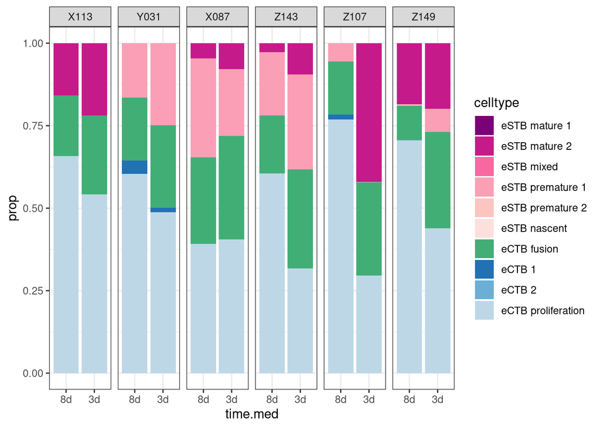

```r
# Generate plotting data frame from theta
foo <- character()
number_of_celltypes <- length(colnames(theta))

for (i in colnames(theta)) {
  foo <- c(foo, rep(i, length(rownames(theta))))
}

df2plot <- data.frame(
  samples   = rep(rownames(theta), number_of_celltypes),
  prop      = as.vector(theta),
  cell_type = foo
)

# Match sample ordering used previously ("ordered by donor")
df2plot$samples <- factor(
  df2plot$samples,
  levels = rownames(theta)[c(1,7,2,8,3,9,4,10,5,11,6,12)]
)

# Colours and ordering
cell_cols <- c(
  # STB lineage
  "eSTB nascent"        = "#FDE0DD",
  "eSTB premature 2"    = "#FCC5C0",
  "eSTB premature 1"    = "#FA9FB5",
  "eSTB mixed"          = "#F768A1",
  "eSTB mature 2"       = "#C51B8A",
  "eSTB mature 1"       = "#7A0177",

  # Fusion
  "eCTB fusion"         = "#41AE76",

  # CTB lineage
  "eCTB proliferation"  = "#BDD7E7",
  "eCTB 2"              = "#6BAED6",
  "eCTB 1"              = "#2171B5"
)

celltype_order <- c(
  "eSTB mature 1",
  "eSTB mature 2",
  "eSTB mixed",
  "eSTB premature 1",
  "eSTB premature 2",
  "eSTB nascent",
  "eCTB fusion",
  "eCTB 1",
  "eCTB 2",
  "eCTB proliferation"
)

df2plot$celltype <- factor(df2plot$cell_type, levels = celltype_order)

df2plot$donor <- factor(
  unlist(strsplit(as.character(df2plot$samples), "_"))[c(TRUE, FALSE, FALSE)],
  levels = c("X113", "Y031", "X087", "Z143", "Z107", "Z149")
)

df2plot$time.med <- factor(
  unlist(strsplit(as.character(df2plot$samples), "_"))[c(FALSE, TRUE, FALSE)],
  levels = c("8d", "3d")
)

# Donor-faceted bar plot
p.bar <- ggplot(df2plot, aes(x = time.med, y = prop, fill = celltype)) +
  geom_col() +
  facet_wrap(~ donor, nrow = 1) +
  scale_fill_manual(values = cell_cols) +
  theme_bw()

p.bar
```

```r
tiff_name <- paste(
  plot_dir,
  "/Figure_2_J.tiff",
  sep = ""
)

tiff(
  filename = tiff_name,
  width = 10,
  height = 7,
  units = "in",
  res = 300,
  compression = "lzw"
)

print(p.bar)

dev.off()
```